# Indicio Mediator Training - Lab 1

## Is it working?

One interesting characteristic of Mediation is that when everything is working, it can be difficult to tell if the connection is actually mediated!

We can test out the connection by sending a basic message from Bob to Alice.

From the **Bob (Admin)** agent window, select **Messages** from the navigation menu.

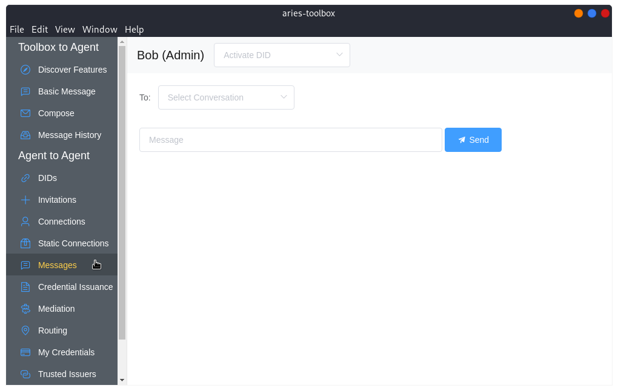

Select **Alice** from the **To** drop down menu.

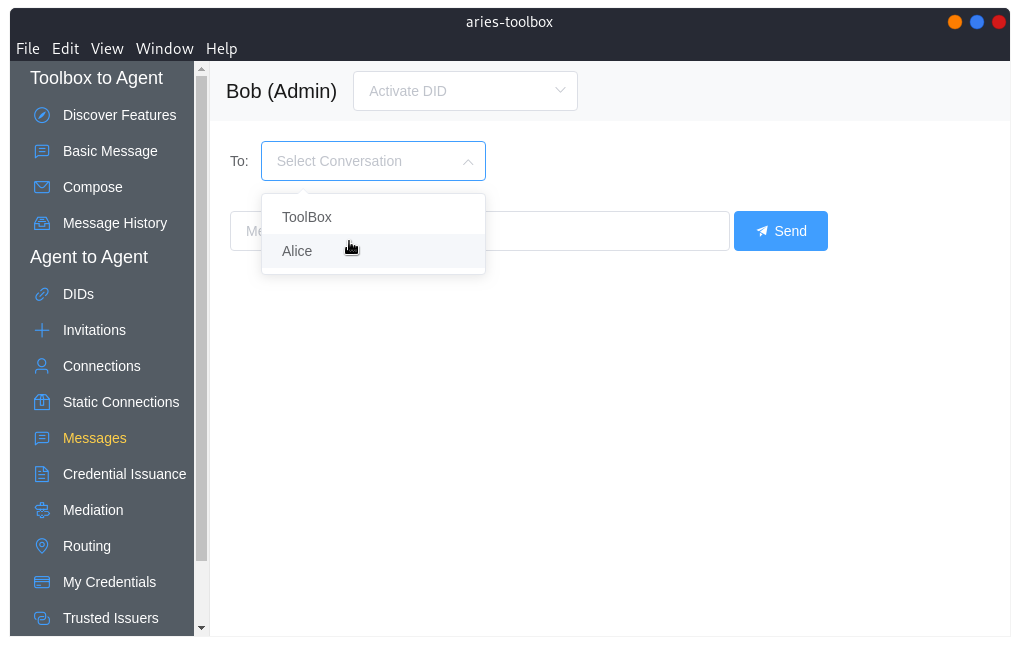

And type out a message for Alice in the **Message** box, followed by clicking **Send**.

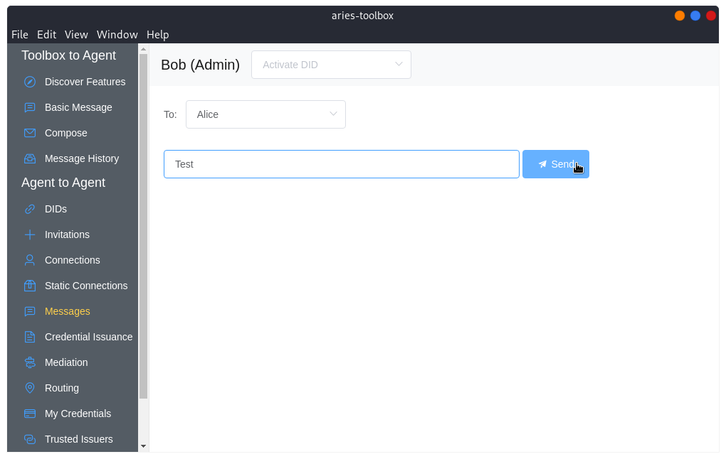

To see if Alice got the message, we will go back to the **Alice (Admin)** agent window and navigate to the **Messages** view. From there, select **Bob** in the **To** drop down menu.

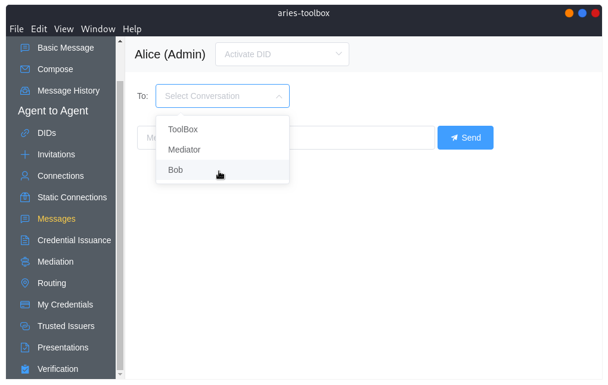

We should then see Bob’s message.

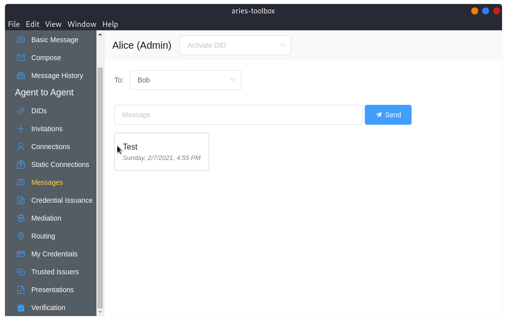

## But is it really mediated?

We have demonstrated that the connection between Alice and Bob is live and working without issue. We now know that mediation isn’t somehow interfering with the connection but we still haven’t seen evidence that mediation is actually occurring. To dig a little deeper, let’s inspect both Alice’s and the Mediator’s view of the mediation state.

Still in the **Alice (Admin)** agent window, navigate to the **Routing** view in the navigation menu.

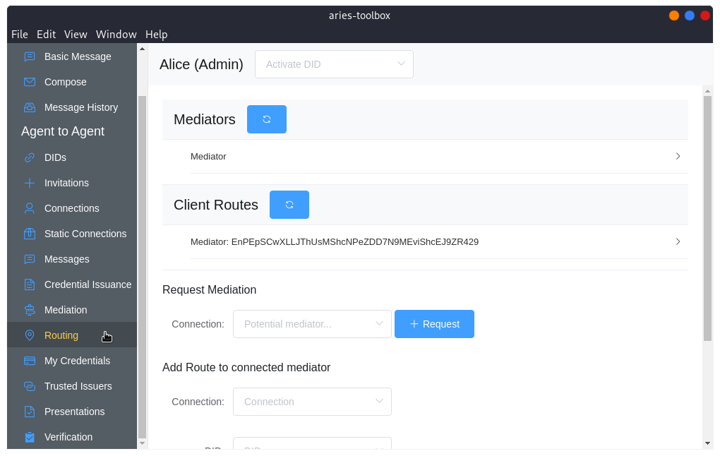

From this view, we see that a new **Client Route** has appeared. This “route” represents an item in the Mediator’s lookup table that Alice reported during the connection protocol with Bob.

Return to the **Mediator (Admin)** agent window and navigate to **Mediation** in the navigation menu.

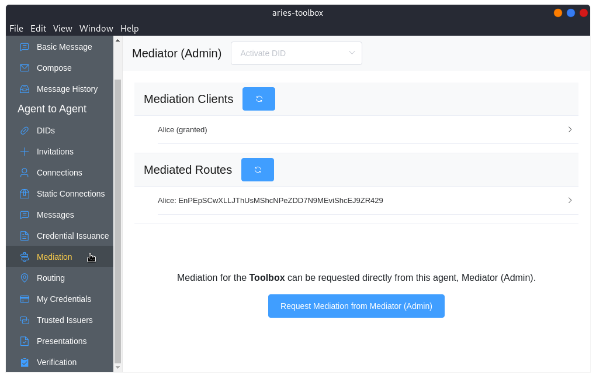

Here we see a new **Mediated Route** has appeared. This “route” represents the same key in the Mediator’s lookup table that we viewed from Alice’s perspective. With that, we can be relatively confident that messages are flowing through the mediator to Alice from Bob.